# CourseProject

Alex Segal

11/28/2019

# Course Project

##Background

Using devices such as Jawbone Up, Nike FuelBand, and Fitbit it is now possible to collect a large amount of data about personal activity relatively inexpensively. These type of devices are part of the quantified self movement – a group of enthusiasts who take measurements about themselves regularly to improve their health, to find patterns in their behavior, or because they are tech geeks. One thing that people regularly do is quantify how much of a particular activity they do, but they rarely quantify how well they do it. In this project, your goal will be to use data from accelerometers on the belt, forearm, arm, and dumbell of 6 participants. They were asked to perform barbell lifts correctly and incorrectly in 5 different ways. More information is available from the website here: http://groupware.les.inf.puc-rio.br/har (see the section on the Weight Lifting Exercise Dataset).

##Data The training data for this project are available here:

https://d396qusza40orc.cloudfront.net/predmachlearn/pml-training.csv

The test data are available here:

https://d396qusza40orc.cloudfront.net/predmachlearn/pml-testing.csv

The data for this project come from this source: http://groupware.les.inf.puc-rio.br/har.

## Initialization

Load packages

```r
library(caret)
```

```r
library(ggplot2)
library(tidyr)
library(dplyr)
library(skimr)
library(visdat)
library(DataExplorer)
library(inspectdf)
```

Load training data/ validation data

```r
buildingData <- read.csv("pml-training.csv")
validationData <- read.csv("pml-testing.csv")
```

For reproducibility set a seed

```r
set.seed(12345)
```

Split the buildingData to Train set and Test set

```r
training_sample <- createDataPartition(y=buildingData$classe, p=0.7, list=FALSE)
trainingData <- buildingData[training_sample, ]
testData <- buildingData[-training_sample, ]
```

## Exploratory Data analysis

In this section we will clean, prepare and manipulate data.

Check the structure of the file

```r
skim(trainingData)
```

Data summary

| Name | trainingData |
| --- | --- |
| Number of rows | 13737 |
| Number of columns | 160 |
| _______________________ |  |
| Column type frequency: |  |
| factor | 37 |
| numeric | 123 |
| ________________________ |  |
| Group variables | None |

**Variable type: factor**

| skim_variable | n_missing | complete_rate | ordered | n_unique | top_counts |
| --- | --- | --- | --- | --- | --- |
| user_name | 0 | 1 | FALSE | 6 | ade: 2719, cha: 2454, jer: 2387, car: 2177 |
| cvtd_timestamp | 0 | 1 | FALSE | 20 | 28/: 1063, 05/: 1040, 30/: 1014, 05/: 996 |
| new_window | 0 | 1 | FALSE | 2 | no: 13454, yes: 283 |
| kurtosis_roll_belt | 0 | 1 | FALSE | 277 | emp: 13454, #DI: 7, -1.: 2, -0.: 1 |
| kurtosis_picth_belt | 0 | 1 | FALSE | 234 | emp: 13454, #DI: 23, 1.2: 3, 2.7: 3 |
| kurtosis_yaw_belt | 0 | 1 | FALSE | 2 | emp: 13454, #DI: 283 |
| skewness_roll_belt | 0 | 1 | FALSE | 275 | emp: 13454, #DI: 7, 0.0: 3, 0.4: 2 |
| skewness_roll_belt.1 | 0 | 1 | FALSE | 244 | emp: 13454, #DI: 23, 0.0: 4, -2.: 3 |
| skewness_yaw_belt | 0 | 1 | FALSE | 2 | emp: 13454, #DI: 283 |
| max_yaw_belt | 0 | 1 | FALSE | 63 | emp: 13454, -1.: 22, -1.: 19, -1.: 18 |
| min_yaw_belt | 0 | 1 | FALSE | 63 | emp: 13454, -1.: 22, -1.: 19, -1.: 18 |
| amplitude_yaw_belt | 0 | 1 | FALSE | 4 | emp: 13454, 0.0: 268, 0.0: 8, #DI: 7 |
| kurtosis_roll_arm | 0 | 1 | FALSE | 232 | emp: 13454, #DI: 53, -0.: 1, -0.: 1 |
| kurtosis_picth_arm | 0 | 1 | FALSE | 230 | emp: 13454, #DI: 55, -0.: 1, -0.: 1 |
| kurtosis_yaw_arm | 0 | 1 | FALSE | 275 | emp: 13454, #DI: 9, 0.6: 2, -0.: 1 |
| skewness_roll_arm | 0 | 1 | FALSE | 232 | emp: 13454, #DI: 53, -0.: 1, -0.: 1 |
| skewness_pitch_arm | 0 | 1 | FALSE | 230 | emp: 13454, #DI: 55, -0.: 1, -0.: 1 |
| skewness_yaw_arm | 0 | 1 | FALSE | 274 | emp: 13454, #DI: 9, -1.: 2, 0.5: 2 |
| kurtosis_roll_dumbbell | 0 | 1 | FALSE | 281 | emp: 13454, -0.: 2, -2.: 2, #DI: 2 |
| kurtosis_picth_dumbbell | 0 | 1 | FALSE | 280 | emp: 13454, -0.: 2, -0.: 2, -2.: 2 |
| kurtosis_yaw_dumbbell | 0 | 1 | FALSE | 2 | emp: 13454, #DI: 283 |
| skewness_roll_dumbbell | 0 | 1 | FALSE | 282 | emp: 13454, #DI: 2, 0.1: 2, -0.: 1 |
| skewness_pitch_dumbbell | 0 | 1 | FALSE | 280 | emp: 13454, -0.: 2, -0.: 2, -0.: 2 |
| skewness_yaw_dumbbell | 0 | 1 | FALSE | 2 | emp: 13454, #DI: 283 |
| max_yaw_dumbbell | 0 | 1 | FALSE | 67 | emp: 13454, -0.: 14, -0.: 13, -0.: 12 |
| min_yaw_dumbbell | 0 | 1 | FALSE | 67 | emp: 13454, -0.: 14, -0.: 13, -0.: 12 |
| amplitude_yaw_dumbbell | 0 | 1 | FALSE | 3 | emp: 13454, 0.0: 281, #DI: 2 |
| kurtosis_roll_forearm | 0 | 1 | FALSE | 219 | emp: 13454, #DI: 65, -0.: 2, -0.: 1 |
| kurtosis_picth_forearm | 0 | 1 | FALSE | 219 | emp: 13454, #DI: 66, -0.: 1, -0.: 1 |
| kurtosis_yaw_forearm | 0 | 1 | FALSE | 2 | emp: 13454, #DI: 283 |
| skewness_roll_forearm | 0 | 1 | FALSE | 219 | emp: 13454, #DI: 65, -0.: 2, -0.: 1 |
| skewness_pitch_forearm | 0 | 1 | FALSE | 216 | emp: 13454, #DI: 66, 0.0: 4, -0.: 1 |
| skewness_yaw_forearm | 0 | 1 | FALSE | 2 | emp: 13454, #DI: 283 |
| max_yaw_forearm | 0 | 1 | FALSE | 36 | emp: 13454, #DI: 65, -1.: 18, -1.: 18 |
| min_yaw_forearm | 0 | 1 | FALSE | 36 | emp: 13454, #DI: 65, -1.: 18, -1.: 18 |
| amplitude_yaw_forearm | 0 | 1 | FALSE | 3 | emp: 13454, 0.0: 218, #DI: 65 |
| classe | 0 | 1 | FALSE | 5 | A: 3906, B: 2658, E: 2525, C: 2396 |

**Variable type: numeric**

| skim_variable | n_missing | complete_rate | mean | sd | p0 | p25 | p50 | p75 | p100 | hist |
| --- | --- | --- | --- | --- | --- | --- | --- | --- | --- | --- |
| X | 0 | 1.00 | 9806.60 | 5670.38 | 1.00000e+00 | 4900.00 | 9815.00 | 14735.00 | 1.962100e+04 | ▇▇▇▇▇ |
| raw_timestamp_part_1 | 0 | 1.00 | 1322826906.54 | 205327.11 | 1.32249e+09 | 1322673099.00 | 1322832920.00 | 1323084264.00 | 1.323095e+09 | ▃▃▇▁▆ |
| raw_timestamp_part_2 | 0 | 1.00 | 499987.04 | 288072.39 | 3.01000e+02 | 252313.00 | 496326.00 | 748319.00 | 9.987500e+05 | ▇▇▇▇▇ |
| num_window | 0 | 1.00 | 430.46 | 248.17 | 1.00000e+00 | 222.00 | 424.00 | 645.00 | 8.640000e+02 | ▇▇▇▇▇ |
| roll_belt | 0 | 1.00 | 64.29 | 62.76 | -2.89000e+01 | 1.09 | 113.00 | 123.00 | 1.620000e+02 | ▇▁▁▅▅ |
| pitch_belt | 0 | 1.00 | 0.32 | 22.32 | -5.49000e+01 | 1.77 | 5.27 | 14.90 | 6.020000e+01 | ▃▁▇▃▁ |
| yaw_belt | 0 | 1.00 | -11.47 | 95.11 | -1.80000e+02 | -88.30 | -13.50 | 12.50 | 1.790000e+02 | ▁▇▅▁▃ |
| total_accel_belt | 0 | 1.00 | 11.30 | 7.74 | 0.00000e+00 | 3.00 | 17.00 | 18.00 | 2.900000e+01 | ▇▁▂▆▁ |
| max_roll_belt | 13454 | 0.02 | -1.16 | 98.10 | -9.43000e+01 | -87.95 | -4.60 | 54.95 | 1.800000e+02 | ▇▅▁▁▅ |
| max_picth_belt | 13454 | 0.02 | 13.10 | 7.91 | 3.00000e+00 | 5.00 | 18.00 | 19.00 | 3.000000e+01 | ▇▁▆▃▁ |
| min_roll_belt | 13454 | 0.02 | -4.52 | 97.32 | -1.80000e+02 | -88.40 | -7.00 | 42.45 | 1.730000e+02 | ▁▇▅▁▅ |
| min_pitch_belt | 13454 | 0.02 | 10.89 | 7.45 | 0.00000e+00 | 3.00 | 16.00 | 17.00 | 2.300000e+01 | ▇▁▁▇▂ |
| amplitude_roll_belt | 13454 | 0.02 | 3.36 | 21.50 | 0.00000e+00 | 0.35 | 1.00 | 2.00 | 3.600000e+02 | ▇▁▁▁▁ |
| amplitude_pitch_belt | 13454 | 0.02 | 2.21 | 2.43 | 0.00000e+00 | 1.00 | 1.00 | 2.00 | 1.200000e+01 | ▇▁▁▁▁ |
| var_total_accel_belt | 13454 | 0.02 | 0.97 | 2.33 | 0.00000e+00 | 0.10 | 0.20 | 0.30 | 1.650000e+01 | ▇▁▁▁▁ |
| avg_roll_belt | 13454 | 0.02 | 69.64 | 63.06 | -1.88000e+01 | 1.10 | 117.00 | 124.00 | 1.574000e+02 | ▇▁▁▅▆ |
| stddev_roll_belt | 13454 | 0.02 | 1.44 | 2.58 | 0.00000e+00 | 0.20 | 0.40 | 0.80 | 1.420000e+01 | ▇▁▁▁▁ |
| var_roll_belt | 13454 | 0.02 | 8.72 | 25.27 | 0.00000e+00 | 0.00 | 0.10 | 0.60 | 2.007000e+02 | ▇▁▁▁▁ |
| avg_pitch_belt | 13454 | 0.02 | -1.14 | 23.00 | -5.14000e+01 | -1.35 | 5.20 | 14.20 | 4.100000e+01 | ▃▁▂▇▂ |
| stddev_pitch_belt | 13454 | 0.02 | 0.61 | 0.67 | 0.00000e+00 | 0.20 | 0.30 | 0.70 | 4.000000e+00 | ▇▂▁▁▁ |
| var_pitch_belt | 13454 | 0.02 | 0.82 | 1.95 | 0.00000e+00 | 0.00 | 0.10 | 0.60 | 1.620000e+01 | ▇▁▁▁▁ |
| avg_yaw_belt | 13454 | 0.02 | -3.33 | 97.46 | -1.38300e+02 | -88.15 | -5.90 | 47.55 | 1.735000e+02 | ▇▁▅▁▃ |
| stddev_yaw_belt | 13454 | 0.02 | 1.06 | 6.53 | 0.00000e+00 | 0.10 | 0.30 | 0.70 | 1.092000e+02 | ▇▁▁▁▁ |
| var_yaw_belt | 13454 | 0.02 | 43.66 | 709.01 | 0.00000e+00 | 0.01 | 0.10 | 0.44 | 1.192847e+04 | ▇▁▁▁▁ |
| gyros_belt_x | 0 | 1.00 | -0.01 | 0.21 | -1.04000e+00 | -0.03 | 0.03 | 0.11 | 2.220000e+00 | ▁▇▁▁▁ |
| gyros_belt_y | 0 | 1.00 | 0.04 | 0.08 | -6.40000e-01 | 0.00 | 0.02 | 0.11 | 6.400000e-01 | ▁▁▇▁▁ |
| gyros_belt_z | 0 | 1.00 | -0.13 | 0.24 | -1.46000e+00 | -0.20 | -0.10 | -0.02 | 1.610000e+00 | ▁▂▇▁▁ |
| accel_belt_x | 0 | 1.00 | -5.63 | 29.63 | -1.20000e+02 | -21.00 | -15.00 | -5.00 | 8.500000e+01 | ▁▁▇▁▂ |
| accel_belt_y | 0 | 1.00 | 30.09 | 28.59 | -6.90000e+01 | 3.00 | 33.00 | 61.00 | 1.640000e+02 | ▁▇▇▁▁ |
| accel_belt_z | 0 | 1.00 | -72.38 | 100.45 | -2.75000e+02 | -162.00 | -152.00 | 28.00 | 1.050000e+02 | ▁▇▁▅▃ |

[output cut: 93 more lines]

Inspect the types of the variables

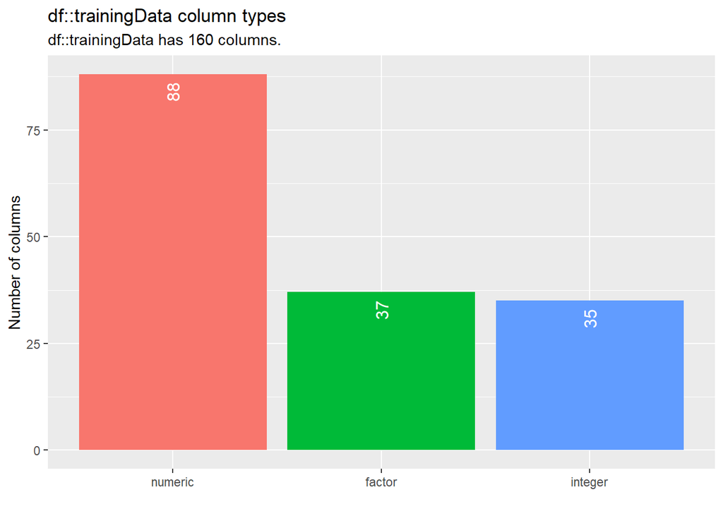

```r
typesdf <- inspect_types(trainingData)
show_plot(typesdf)
```

Inspect the NAs in the dataset

```r
nadf <- inspect_na(trainingData)
```

Number of raws in the training dataset

```r
Len_train <- dim(trainingData)[1]
```

Select the variables that don’t contain information in most of the entries.

```r
SelectVoidCols1 <- which(colSums(is.na(trainingData) |trainingData=="")>0.75*Len_train)
```

Remove the unnecesary variables from the data set

```r
trainingData1 <- trainingData[,-SelectVoidCols1]
```

As well remove all the unnecesary columns, like X, timestamps etc.

```r
trainingData2 <- trainingData1[,-c(1:7)]
```

Remove from the TEST data set the same variables that were removed from the train data set.

```r
testData1 <- testData[,-SelectVoidCols1]
testData2 <- testData1[,-c(1:7)]
```

## Training the model

### Cross Validation

```r
trcont <- trainControl(method="repeatedcv", number=5, repeats=1)
```

The first model we will train is the RandomForest

```r
model.RF <- train(classe~., data=trainingData2, method="rf" ,trControl=trcont, verbose=FALSE)
print(model.RF)
```

```
## Random Forest
##
## 13737 samples
##    52 predictor
##     5 classes: 'A', 'B', 'C', 'D', 'E'
##
## No pre-processing
## Resampling: Cross-Validated (5 fold, repeated 1 times)
## Summary of sample sizes: 10987, 10990, 10990, 10991, 10990
## Resampling results across tuning parameters:
##
##   mtry  Accuracy   Kappa
##    2    0.9911914  0.9888567
##   27    0.9902453  0.9876601
##   52    0.9846405  0.9805695
##
## Accuracy was used to select the optimal model using the largest value.
## The final value used for the model was mtry = 2.
```

The second model we will train is the Generailized Boosting Machine (GBM)

```r
model.GBM <- train(classe~., data=trainingData2, method="gbm" ,trControl=trcont, verbose=FALSE)
print(model.GBM)
```

```
## Stochastic Gradient Boosting
##
## 13737 samples
##    52 predictor
##     5 classes: 'A', 'B', 'C', 'D', 'E'
##
## No pre-processing
## Resampling: Cross-Validated (5 fold, repeated 1 times)
## Summary of sample sizes: 10990, 10989, 10990, 10990, 10989
## Resampling results across tuning parameters:
##
##   interaction.depth  n.trees  Accuracy   Kappa
##   1                   50      0.7481249  0.6805265
##   1                  100      0.8184469  0.7701804
##   1                  150      0.8534617  0.8145854
##   2                   50      0.8580476  0.8201258
##   2                  100      0.9074033  0.8828265
##   2                  150      0.9319359  0.9138861
##   3                   50      0.8975034  0.8702664
##   3                  100      0.9422732  0.9269749
##   3                  150      0.9611997  0.9509124
##
## Tuning parameter 'shrinkage' was held constant at a value of 0.1
##
## Tuning parameter 'n.minobsinnode' was held constant at a value of 10
## Accuracy was used to select the optimal model using the largest value.
## The final values used for the model were n.trees = 150,
##  interaction.depth = 3, shrinkage = 0.1 and n.minobsinnode = 10.
```

##Testing —- In this section we will assess the predictions of our model on the test data, i.e. the data that “has not been seen” by our models.

Prediction using random forests

```r
TestPredict.RF <- predict(model.RF,newdata=testData)
ConfMat.RF <- confusionMatrix(testData$classe,TestPredict.RF)
ConfMat.RF$table
```

```
##           Reference
## Prediction    A    B    C    D    E
##          A 1673    1    0    0    0
##          B    4 1135    0    0    0
##          C    0    8 1017    1    0
##          D    0    0   22  940    2
##          E    0    0    0    1 1081
```

```r
ConfMat.RF$overall[1]
```

```
## Accuracy
## 0.993373
```

Prediction using GBM

```r
TestPredict.GBM <- predict(model.GBM,newdata=testData)
ConfMat.GBM <- confusionMatrix(testData$classe,TestPredict.GBM)
ConfMat.GBM$table
```

```
##           Reference
## Prediction    A    B    C    D    E
##          A 1643   20    4    7    0
##          B   45 1056   35    1    2
##          C    0   34  980   11    1
##          D    3    5   36  916    4
##          E    0   10    6   10 1056
```

```r
ConfMat.GBM$overall[1]
```

```
##  Accuracy
## 0.9602379
```

## Conlcusion

The Random Forest method produces more accurate results, therefore it will be used for the Course Project Prediction Quiz as follows

```r
ValidPredict.GBM <- predict(model.RF,newdata=validationData)
Results <- cbind(validationData,Pred=ValidPredict.GBM)[,c(160,161)]
print(Results)
```

```
##    problem_id Pred
## 1           1    B
## 2           2    A
## 3           3    B
## 4           4    A
## 5           5    A
## 6           6    E
## 7           7    D
## 8           8    B
## 9           9    A
## 10         10    A
## 11         11    B
## 12         12    C
## 13         13    B
## 14         14    A
## 15         15    E
## 16         16    E
## 17         17    A
## 18         18    B
## 19         19    B
## 20         20    B
```